# Regression Project

Cesar Espitia

July 9, 2015

## Executive Summary - Motor Trends

The purpose of this project was to determine the relationship between a set of variables and the vehicles fuel efficiency quantified as MPG. Specifically the following:

- which transmission has better MPG, Automatic or Manual?
- expalin the differences between them

Fromt he analysis to follow, it became clear tha although there are quantifiable differences in one transmission type being better than the other, other more appropriable variabels were better estimates of fuel efficiency. In addition, the data set would benefit from having more data points (n>32; perhaps n>100) in order to have higher degrees of confidence in the results.

## Data Preparation

The data is already a part of the R library of data related and doesn’t require much manipulation. For the purposes of this exercise, the variables cyl, vs, gear, carb and am were coerced into factors in order to better understand the ffects on the regression model as they are binary / categorical in nature and truly continuous.

```r
#load and store data
library(datasets)
library(ggplot2)
library(caret)
library(dplyr)
cars <- mtcars
cars$cyl  <- factor(cars$cyl)
cars$vs   <- factor(cars$vs)
cars$gear <- factor(cars$gear)
cars$carb <- factor(cars$carb)
cars$am <- factor(cars$am, labels=c("Auto","Man"))
```

## Exploratory Analysis

### Box Plot - Transmission vs. MPG

A boxplot was chosen to visualize the correlation between transmission and fuel efficiency, the data points were also overlayed to determine if any outliers exist.

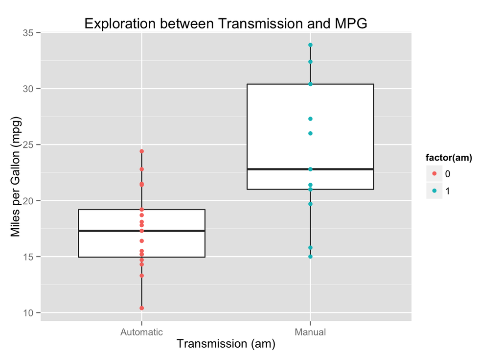

```r
#note Automatic = 0, Manual = 1
ggplot(mtcars, aes(factor(am), mpg))+geom_boxplot()+geom_point(aes(color=factor(am)))+scale_x_discrete(labels=c("Automatic","Manual"))+xlab("Transmission (am)") + ylab("Miles per Gallon (mpg)") + ggtitle("Exploration between Transmission and MPG")
```

In revieweing the data, it is clear that vehicles with a Manual transmission have better MPG, but if you look closely the variability is quite large while the variability in the Automatic category is less. We can quantify this with a two-sample t-test and determine if determine if the null hypothesis (H0: no difference between Manual and Automatic) is valid or should be reject.

```r
ttest <- t.test(mpg~am, data=cars)
ttest$p.value
```

```
## [1] 0.001373638
```

With a P Value of 0.0014, we can reject the null hypothesis. There is a difference between the categories.